# Dimension reduction with PCA

Adam Dudek

23.02.2021

## Dimension reduction with PCA

### What is dimension reduction and why it is useful?

#### Dimension reduction is a type of process of data transformation, where number of variables in the model is reduceded and a new set of new variables is created in the model. In other words, it is a transformation of data from high-dimensional space into a low-dimensional space without loss of a lot meaningfull informations from original dataset.

It helps analysing data much faster, as working in high-dimensional datasets is often computationally intractable and more time consuming. Nowadays dimensionality reduction is common in fields that deal with large numbers of observations and can be used for noise reduction, data visualization, cluster analysis, or as an intermediate step to facilitate other analyses.

#### Methods of dimnension reduction are commonly divided into linear and non-linear approaches. Approaches can also be divided into:

- feature selection approach, where we try to find a subset of the input variables
- feature extraction approach, where we try to reduce number of dimensions, by building a new feature set from the original feature set either by generating features which are composites of existing features or by some other logic.

There are two common methods to perform feature extraction. They are, Principal component analysis (PCA) & Linear discriminant analysis (LDA).

#### In this paper Im gonna explain how one of the most popular linear data transformation, Principal Component Analysis, works and present its outcome while analysing the photo.

## Principal Component analysis

#### As it was mentioned before, PCA is a dimensionality-reduction method that is often used to reduce the dimensionality of large data sets, by transforming a large set of variables into a smaller one that still contains most of the information in the large set.

Reducing the number of variables of a data set naturally comes at the expense of accuracy, but the trick in dimensionality reduction is to trade a little accuracy for simplicity. Because smaller data sets are easier to explore and visualize and make analyzing data much easier and faster for machine learning algorithms without extraneous variables to process. *

### HOW PCA CONSTRUCTS THE PRINCIPAL COMPONENTS?

As there are as many principal components as there are variables in the data, principal components are constructed in such a manner that the first principal component accounts for the largest possible variance in the data set. For example, lets assume that the scatter plot of our data set is as shown below, can we guess the first principal component ? Yes, its approximately the line that matches the purple marks because it goes through the origin and its the line in which the projection of the points (red dots) is the most spread out. Or mathematically speaking, its the line that maximizes the variance (the average of the squared distances from the projected points (red dots) to the origin).

The second principal component is calculated in the same way, with the condition that it is uncorrelated with (i.e., perpendicular to) the first principal component and that it accounts for the next highest variance.

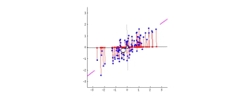

### PCA for NBA data

Lets say we want to check how PCA will perform on data from NBA games. We have a final table of 2019 NBA results.

```r
X <- read.csv("https://drive.google.com/uc?export=download&id=1iv6Rf5rbK4RM3gNl1_ADsfp2EEn0LIfm", sep=";",dec=",",header=T, stringsAsFactors=F)
X<-X[2:30,1:28]
head(X)
```

```
##   ď.ż               TEAM GP  W  L WIN.  MIN   PTS  FGM  FGA  FG. X3PM X3PA X3P.
## 2   2 Los Angeles Lakers 60 47 13 0.78 48.2 114.6 43.1 88.6 48.7 11.2 31.2 35.9
## 3   3    Toronto Raptors 61 43 18 0.71 48.3 113.0 40.7 88.8 45.8 13.7 36.8 37.2
## 4   4        LA Clippers 61 42 19 0.69 48.2 116.1 41.7 89.8 46.5 12.1 32.9 36.8
## 5   5     Boston Celtics 60 41 19 0.68 48.4 113.5 41.3 89.5 46.2 12.5 34.2 36.4
## 6   6     Denver Nuggets 61 41 20 0.67 48.5 110.7 41.8 89.1 47.0 10.8 30.1 35.7
## 7   7    Houston Rockets 60 39 21 0.65 48.3 118.9 41.4 91.0 45.4 15.7 44.6 35.1
##    FTM  FTA  FT. OREB DREB  REB   AST   TOV  STL  BLK BLKA    PF   PFD X...
## 2 17.2 23.6 72.6 10.7 35.4 46.1 26,10 15,10 8,60 6,90 3,80 20,40 21,20  7.5
## 3 17.9 22.5 79.7  9.8 35.5 45.3 25,40 14,50 8,80 5,00 5,30 21,60 19,90  6.4
## 4 20.6 26.0 79.2 10.9 36.9 47.8 24,00 14,80 7,20 5,00 5,00 22,00 22,80  6.3
## 5 18.4 22.9 80.0 10.6 35.4 45.9 23,10 13,80 8,30 5,60 5,50 21,60 20,60  6.5
## 6 16.3 21.0 77.5 11.0 33.6 44.6 26,50 13,60 8,00 4,70 4,60 20,00 20,20  3.2
## 7 20.5 26.0 78.9 10.3 34.9 45.2 21,50 14,50 8,50 5,20 5,10 21,50 20,90  4.6
```

[output not shown]

```r
X <- X[,c("WIN.", "MIN","PTS",  "FGM",  "FGA" , "FG." , "X3PM", "X3PA","X3P.", "FTM","FTA" , "FT.", "OREB", "DREB", "REB"  ,"AST", "TOV",  "STL",  "BLK" , "BLKA" ,"PF"  , "PFD")]

lin_model<- lm(WIN.~.,data=X)
summary(lin_model)
```

```
##
## Call:
## lm(formula = WIN. ~ ., data = X)
##
## Residuals:
##       Min        1Q    Median        3Q       Max
## -0.091701 -0.028413 -0.005587  0.029666  0.094204
##
## Coefficients:
##              Estimate Std. Error t value Pr(>|t|)
## (Intercept) -5.983419  25.961347  -0.230    0.824
## MIN         -0.021138   0.151269  -0.140    0.893
## PTS          0.494725   0.662164   0.747    0.479
## FGM         -1.075369   1.636929  -0.657    0.532
## FGA         -0.001532   0.279697  -0.005    0.996
## FG.          0.142946   0.538249   0.266    0.798
## X3PM        -0.827735   0.825833  -1.002    0.350
## X3PA         0.131872   0.209541   0.629    0.549
## X3P.         0.123780   0.212908   0.581    0.579
## FTM         -0.322008   0.857816  -0.375    0.718
## FTA         -0.141572   0.921574  -0.154    0.882
## FT.         -0.032157   0.302173  -0.106    0.918
## OREB        -0.003407   1.006250  -0.003    0.997
## DREB        -0.024281   0.949042  -0.026    0.980
## REB          0.069596   0.947518   0.073    0.944
## AST         -0.001111   0.018846  -0.059    0.955
## TOV         -0.045217   0.062927  -0.719    0.496
## STL          0.078552   0.044289   1.774    0.119
## BLK          0.018097   0.048800   0.371    0.722
## BLKA        -0.024130   0.116215  -0.208    0.841
## PF           0.016742   0.029676   0.564    0.590
## PFD         -0.003475   0.062245  -0.056    0.957
##
## Residual standard error: 0.09633 on 7 degrees of freedom
## Multiple R-squared:  0.9062, Adjusted R-squared:  0.6248
## F-statistic: 3.221 on 21 and 7 DF,  p-value: 0.05892
```

As we can see basic statistics explain 90.6% of variance. It is a good result, while luck in sport plays a huge role. To obtain this result 21 variables were used. Now e will try to perform PCA analysis.

```r
PCA_NBA<- prcomp(X,center = TRUE,scale=TRUE)
summary(PCA_NBA)
```

```
## Importance of components:
##                           PC1    PC2    PC3     PC4     PC5     PC6     PC7
## Standard deviation     2.3428 1.9278 1.6568 1.46259 1.24831 1.20970 1.04889
## Proportion of Variance 0.2495 0.1689 0.1248 0.09723 0.07083 0.06652 0.05001
## Cumulative Proportion  0.2495 0.4184 0.5432 0.64042 0.71125 0.77776 0.82777
##                           PC8     PC9    PC10    PC11    PC12    PC13    PC14
## Standard deviation     0.9872 0.83095 0.80796 0.68888 0.57309 0.50529 0.46973
## Proportion of Variance 0.0443 0.03139 0.02967 0.02157 0.01493 0.01161 0.01003
## Cumulative Proportion  0.8721 0.90346 0.93313 0.95470 0.96963 0.98123 0.99126
##                           PC15    PC16    PC17    PC18    PC19    PC20     PC21
## Standard deviation     0.29014 0.25973 0.19849 0.02477 0.01782 0.01135 0.009212
## Proportion of Variance 0.00383 0.00307 0.00179 0.00003 0.00001 0.00001 0.000000
## Cumulative Proportion  0.99509 0.99816 0.99995 0.99998 0.99999 1.00000 1.000000
##                            PC22
## Standard deviation     0.004104
## Proportion of Variance 0.000000
## Cumulative Proportion  1.000000
```

Recall that a property of PCA is that our components are sorted from largest to smallest with regard to their standard deviation (Eigenvalues). So lets make sense of these:

- Standard deviation: This is simply the eigenvalues in our case since the data has been centered and scaled (standardized)
- Proportion of Variance: This is the amount of variance the component accounts for in the data, ie. PC1 accounts for 25% of total variance in the data alone!
- Cumulative Proportion: This is simply the accumulated amount of explained variance, ie. if we used the first 10 components we would be able to account for >93% of total variance in the data.

```r
#niewidoczne
Cumulative_variance <- data.frame(c("PC1","PC2","PC3","PC4","PC5","PC6","PC7","PC8","PC9"), c(0.2495, 0.4184, 0.5432 ,0.64042 ,0.71125 ,0.77776, 0.82777 ,0.8721, 0.90346))
colnames(Cumulative_variance)<- c("PC","Cumulative_Variance_explained" )
```

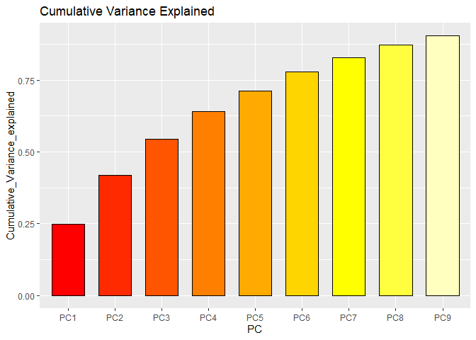

```r
library(ggplot2)
ggplot(Cumulative_variance, aes(x=PC, y=Cumulative_Variance_explained)) +
geom_bar(stat= "identity",color="black",fill = heat.colors(9), width=0.7)+
ggtitle("Cumulative Variance Explained")
```

When we see how PCA can help us reduce multidimensionality of data, lets have a look how it can be used to compress image.